# Exploration Visualization Tool!

5/22/2017

## Problem: exploring your data is hard

At the beginning of every data analysis, there is an exploratory phase. - What are the key variables? - How do they relate? - What are their distributions?

Unfortunately, analyzing each of them requires constant r coding and tweaking. Take for example, the mtcars data set, a common set used for r students.

## Problem: Exploring Your Data is Hard

If I wanted to check out a scatterplot of Weight by MPG, I may write a simple ggplot. But modifying it to the chart on the right means you have to remember how to add the color aethetic.

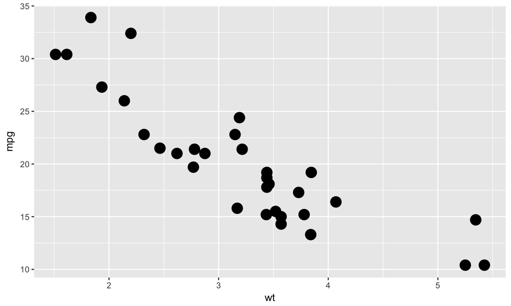

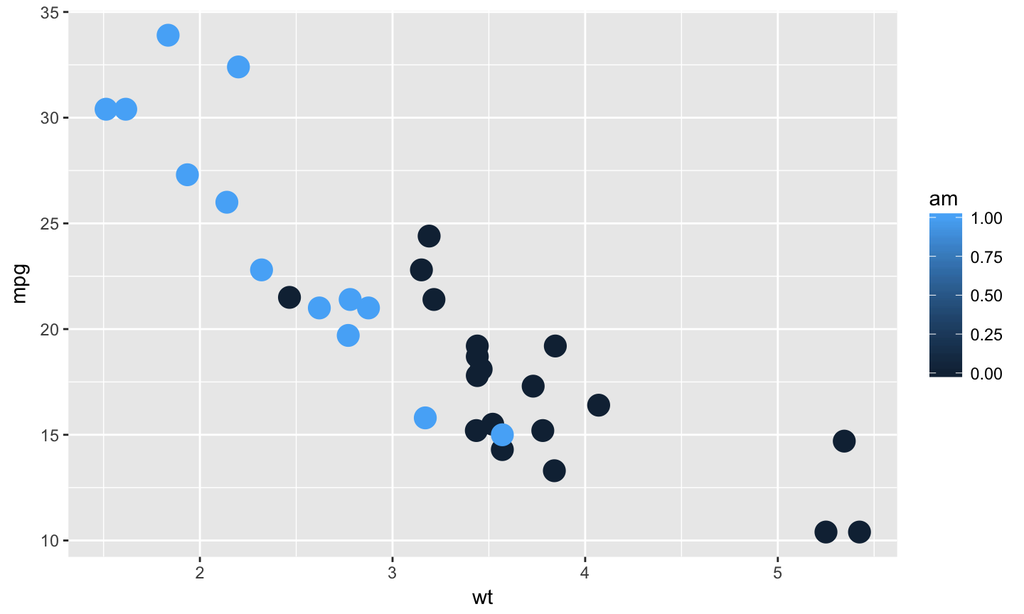

```r
ggplot(mtcars, aes(x=wt, y=mpg)) + geom_point(size=5)
ggplot(mtcars, aes(x=wt, y=mpg, color=am)) + geom_point(size=5)
```

## Solution: Use an Exploration Visualization Tool

But doing this by every variable combination can take a lot of time. What if you could could just select from a drop down, and have the charts generate for you?

Exploration Visualization Tool does this exact thing by use of Shiny's interactivity. Here is some sample code. This one is for show only; it won't run without the rest of the special Shiny secret sauce:

```r
        output$Scatter1<-renderPlot({
        ggplot(mtcars, aes_string(x=input$varname1,
        y="mpg", color=input$varname2)) + geom_point(size=5)
        })
```

## The tool in action

Check out the tool in action:

[figure not shown]

Thank you!